# Data Analysis with R

Monika Avila Marquez, Ph.D.

2024-02-25

In this lab, you will learn how to use the package tidyverse for data anlysis as well as alternative methods without use of this package.

Note: When you execute code within the notebook, the results appear beneath the code. Execute chunks of code by clicking the *Run* button within the chunk or by placing your cursor inside it and pressing *Cmd+Shift+Enter*.

# Step 1. UPLOAD LIBRARIES

The first step is to upload the libraries that you will use. If the library has never been installed, you need to use install.packages() command.

```r
#install.packages("tidyverse")
#install.packages("mice")
#install.packages("finalfit")
#install.packages('naniar')

library(mice)
library(tidyverse)
```

```r
library(ggplot2)
library(finalfit)
library(naniar)
library(ggplot2)
```

# Step 2. CHANGE WORKING DIRECTORY

```r
getwd()
```

```
## [1] "/Users/moka/Dropbox/0.POST-PHD/GOALS/2.CODE/R/Data Analysis with R/DataAnalysisR/Data-Analysis-with-R"
```

```r
setwd("/Users/moka/Dropbox/0.POST-PHD/GOALS/2.CODE/R/Data Analysis with R")
```

# Step 3. UPLOAD DATSET

```r
# Upload data
  # Using tidyverse package
  df_tidy<-read_csv("Data/raw_data.csv")
```

```
## ──────────────────────────────────────────────────────── Delimiter: "," dbl
## (32): cedulam, year, bajo2500, peso, apgar1, apgar2, semgest, premature,...
```

```r
  # Check data set
  glimpse(df_tidy)
```

```
## Rows: 196,704
## Columns: 32
## $ cedulam          <dbl> 10, 11, 12, 13, 14, 17, 18, 20, 22, 23, 24, 25, 26, 2…
## $ year             <dbl> 2005, 2007, 2004, 2004, 2003, 2004, 2005, 2003, 2007,…
## $ bajo2500         <dbl> 0, 1, 0, 0, 0, 0, 0, 0, 0, 0, 1, 0, 0, 0, 0, 0, 0, 0,…
## $ peso             <dbl> 3760, 1100, 3140, 2910, 3050, 3400, 3490, 3180, 3350,…
## $ apgar1           <dbl> 7, 1, 8, 7, 8, 9, 9, 9, 9, 9, 9, 8, 9, 9, 9, 9, 6, 7,…
## $ apgar2           <dbl> 9, 2, 9, 9, 9, 10, 10, 10, 10, 10, 10, 9, 10, 10, 10,…
## $ semgest          <dbl> 39, 30, 38, 37, 40, 39, 39, 40, 41, 39, 37, 37, 40, 3…
## $ premature        <dbl> 0, 1, 0, 0, 0, 0, 0, 0, 0, 0, 0, 0, 0, 0, 0, 0, 0, 0,…
## $ mpeso_areares    <dbl> 3148.675, NA, 3135.173, 3148.675, 3145.420, NA, NA, 3…
## $ totcons          <dbl> 8, 0, 9, 7, 10, 7, 2, 5, 13, 14, 6, 2, 12, 10, 9, 6, …
## $ semprim          <dbl> 17, NA, 18, 13, 15, 27, 25, 19, 9, 22, 15, 14, 10, 4,…
## $ prim             <dbl> 0, 0, 0, 0, 0, 0, 0, 0, 2, 0, 0, 0, 1, 3, 2, 0, NA, 1…
## $ seg              <dbl> 2, 0, 4, 4, 2, 3, 0, 1, 2, 2, 3, 1, 3, 1, 2, 1, NA, 3…
```

[output cut: 19 more lines]

```r
  # Alternative method without using tidyverse package
  df<-read.csv("Data/raw_data.csv")

  # Check if data was correctly uploaded
  head(df)
```

```
##   cedulam year bajo2500 peso apgar1 apgar2 semgest premature mpeso_areares
## 1      10 2005        0 3760      7      9      39         0      3148.675
## 2      11 2007        1 1100      1      2      30         1            NA
## 3      12 2004        0 3140      8      9      38         0      3135.173
## 4      13 2004        0 2910      7      9      37         0      3148.675
## 5      14 2003        0 3050      8      9      40         0      3145.420
## 6      17 2004        0 3400      9     10      39         0            NA
##   totcons semprim prim seg ter    mpeso public medico numemban outofwedlock
## 1       8      17    0   2   6 3273.962      0      1        0            1
## 2       0      NA    0   0   0 3210.299      1      1        0            1
## 3       9      18    0   4   5 3073.221      1      1        8            0
## 4       7      13    0   4   3 3121.745      0      1        2            0
## 5      10      15    0   2   8 3073.221      1      1        0            1
## 6       7      27    0   3   4 3073.221      1      1        4            1
##   missinfof motherworks ing_alljobs9 ing_tot_hh9 ing_alljobs_hh9 edadm edadp
```

[output cut: 20 more lines]

# Step 4. DATA PRE-ANALYSIS AND PRE-PROCESSING

We will use the a dataset provided by Verónica Amarante, Marco Manacorda, Edward Miguel and Andrea Vigorito in the replication materials of the paper “Do Cash Transfers Improve Birth Outcomes? Evidence from Matched Vital Statistics, Program and Social Security Data” published American Economic Journal: Economic Policy in 2016.

## 4.1 Keep only variables of interest

```r
# Using tidyverse package
df_subset_tidy<-select(df,"cedulam","year","bajo2500","peso","apgar1","apgar2","semgest","premature","mpeso_areares","totcons","semprim","prim","seg","ter","mpeso","public","medico","numemban","outofwedlock","missinfof","motherworks.1","ing_alljobs9","ing_tot_hh9","ing_alljobs_hh9","edadm","edadp","motherworks.1","ing_ben_hh9","ever_ing_ciud_hh","ing_ciud_txu_hh9","ing_tarjeta_hh9","ing_ben_hh9.1")
  # Check if data was correctly uploaded
  head(df_subset_tidy)
```

```
##   cedulam year bajo2500 peso apgar1 apgar2 semgest premature mpeso_areares
## 1      10 2005        0 3760      7      9      39         0      3148.675
## 2      11 2007        1 1100      1      2      30         1            NA
## 3      12 2004        0 3140      8      9      38         0      3135.173
## 4      13 2004        0 2910      7      9      37         0      3148.675
## 5      14 2003        0 3050      8      9      40         0      3145.420
## 6      17 2004        0 3400      9     10      39         0            NA
##   totcons semprim prim seg ter    mpeso public medico numemban outofwedlock
## 1       8      17    0   2   6 3273.962      0      1        0            1
## 2       0      NA    0   0   0 3210.299      1      1        0            1
## 3       9      18    0   4   5 3073.221      1      1        8            0
## 4       7      13    0   4   3 3121.745      0      1        2            0
## 5      10      15    0   2   8 3073.221      1      1        0            1
## 6       7      27    0   3   4 3073.221      1      1        4            1
##   missinfof motherworks.1 ing_alljobs9 ing_tot_hh9 ing_alljobs_hh9 edadm edadp
## 1         0             0            0           0               0    17    19
## 2         1             0            0           0               0    31  9999
## 3         0             0           NA          NA              NA    41    45
## 4         0             0            0           0               0    26    30
## 5         1             0           NA          NA              NA    24  9999
## 6         0             0           NA          NA              NA    32    29
##   ing_ben_hh9 ever_ing_ciud_hh ing_ciud_txu_hh9 ing_tarjeta_hh9 ing_ben_hh9.1
## 1           0               NA                0               0             0
## 2           0               NA                0               0             0
## 3          NA               NA                0               0            NA
## 4           0               NA                0               0             0
## 5          NA               NA                0               0            NA
## 6          NA               NA                0               0            NA
```

```r
# Alternative method without using tidyverse package
  df_subset<-df[,c("cedulam","year","bajo2500","peso","apgar1","apgar2","semgest","premature","mpeso_areares","totcons","semprim","prim","seg","ter","mpeso","public","medico","numemban","outofwedlock","missinfof","motherworks.1","ing_alljobs9","ing_tot_hh9","ing_alljobs_hh9","edadm","edadp","motherworks.1","ing_ben_hh9","ever_ing_ciud_hh","ing_ciud_txu_hh9","ing_tarjeta_hh9","ing_ben_hh9.1")]
  # Check if data was correctly uploaded
  head(df_subset)
```

```
##   cedulam year bajo2500 peso apgar1 apgar2 semgest premature mpeso_areares
## 1      10 2005        0 3760      7      9      39         0      3148.675
## 2      11 2007        1 1100      1      2      30         1            NA
## 3      12 2004        0 3140      8      9      38         0      3135.173
## 4      13 2004        0 2910      7      9      37         0      3148.675
## 5      14 2003        0 3050      8      9      40         0      3145.420
## 6      17 2004        0 3400      9     10      39         0            NA
##   totcons semprim prim seg ter    mpeso public medico numemban outofwedlock
## 1       8      17    0   2   6 3273.962      0      1        0            1
## 2       0      NA    0   0   0 3210.299      1      1        0            1
## 3       9      18    0   4   5 3073.221      1      1        8            0
## 4       7      13    0   4   3 3121.745      0      1        2            0
## 5      10      15    0   2   8 3073.221      1      1        0            1
## 6       7      27    0   3   4 3073.221      1      1        4            1
##   missinfof motherworks.1 ing_alljobs9 ing_tot_hh9 ing_alljobs_hh9 edadm edadp
```

[output cut: 20 more lines]

```r
  # Another way of subsetting the data

  vbles_interest<-c("cedulam","year","bajo2500","peso","apgar1","apgar2","semgest","premature","mpeso_areares","totcons","semprim","prim","seg","ter","mpeso","public","medico","numemban","outofwedlock","missinfof","motherworks.1","ing_alljobs9","ing_tot_hh9","ing_alljobs_hh9","edadm","edadp","motherworks.1","ing_ben_hh9","ever_ing_ciud_hh","ing_ciud_txu_hh9","ing_tarjeta_hh9","ing_ben_hh9.1")

  df_subset2<-df[,vbles_interest]

  # Check if data was correctly uploaded
  head(df_subset2)
```

```
##   cedulam year bajo2500 peso apgar1 apgar2 semgest premature mpeso_areares
## 1      10 2005        0 3760      7      9      39         0      3148.675
## 2      11 2007        1 1100      1      2      30         1            NA
## 3      12 2004        0 3140      8      9      38         0      3135.173
## 4      13 2004        0 2910      7      9      37         0      3148.675
## 5      14 2003        0 3050      8      9      40         0      3145.420
## 6      17 2004        0 3400      9     10      39         0            NA
##   totcons semprim prim seg ter    mpeso public medico numemban outofwedlock
## 1       8      17    0   2   6 3273.962      0      1        0            1
## 2       0      NA    0   0   0 3210.299      1      1        0            1
## 3       9      18    0   4   5 3073.221      1      1        8            0
## 4       7      13    0   4   3 3121.745      0      1        2            0
## 5      10      15    0   2   8 3073.221      1      1        0            1
## 6       7      27    0   3   4 3073.221      1      1        4            1
##   missinfof motherworks.1 ing_alljobs9 ing_tot_hh9 ing_alljobs_hh9 edadm edadp
```

[output cut: 20 more lines]

You can find another data manupalation examples in the following link:https://tavareshugo.github.io/r-intro-tidyverse-gapminder/04-manipulate_variables_dplyr/index.html

## 4.2 Verify that variables have the correct type

```r
head(df_subset)
```

```
##   cedulam year bajo2500 peso apgar1 apgar2 semgest premature mpeso_areares
## 1      10 2005        0 3760      7      9      39         0      3148.675
## 2      11 2007        1 1100      1      2      30         1            NA
## 3      12 2004        0 3140      8      9      38         0      3135.173
## 4      13 2004        0 2910      7      9      37         0      3148.675
## 5      14 2003        0 3050      8      9      40         0      3145.420
## 6      17 2004        0 3400      9     10      39         0            NA
##   totcons semprim prim seg ter    mpeso public medico numemban outofwedlock
## 1       8      17    0   2   6 3273.962      0      1        0            1
## 2       0      NA    0   0   0 3210.299      1      1        0            1
## 3       9      18    0   4   5 3073.221      1      1        8            0
## 4       7      13    0   4   3 3121.745      0      1        2            0
## 5      10      15    0   2   8 3073.221      1      1        0            1
## 6       7      27    0   3   4 3073.221      1      1        4            1
##   missinfof motherworks.1 ing_alljobs9 ing_tot_hh9 ing_alljobs_hh9 edadm edadp
```

[output cut: 20 more lines]

## 4.3 Look for missing values

Missing values are represented by NA.

Important:

- NA is not the same as NaN! NaN means that it is not a number.
- Inf means that it is undefined (ex. 1/0) or infinity.

Useful package to deal with missing values are mice, tidyverse, naniar.

### 4.3.1. Percentage of ALL data frame values that are missing

```r
pct_miss(df_subset)
```

```
## [1] 10.32314
```

### 4.3.2. Percentage of complete cases

```r
pct_complete_case(df_subset)
```

```
## [1] 13.35662
```

### 4.3.3. Percentage of rows with any missing value

```r
pct_miss_case(df_subset)
```

```
## [1] 86.64338
```

### 4.3.4. Determine if the variable mpeso_areare has missing values.

```r
head(is.na(df_subset$mpeso_areare))
```

```
## [1] FALSE  TRUE FALSE FALSE FALSE  TRUE
```

### 4.3.5. Finding the number of missing values for the variable mpeso_areare.

```r
# Using tidyverse packages
df_subset %>%
  summarise(count = sum(is.na(df_subset$mpeso_areares)))
```

```
##   count
## 1  8123
```

### 4.3.6. Get a plot with missing values frequencies for each variable

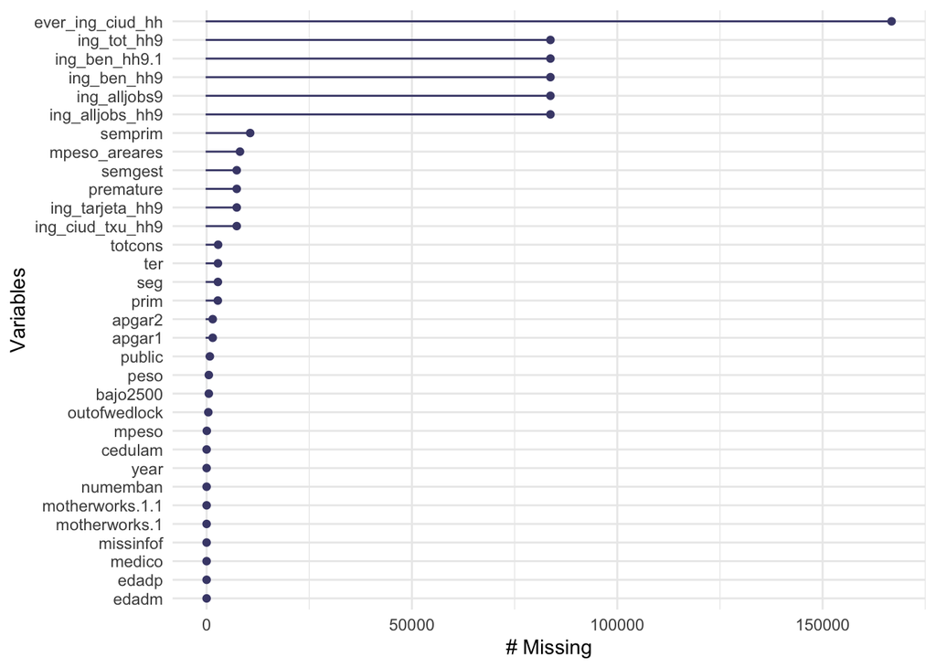

```r
gg_miss_var(df_subset)
```

### 4.3.7. Missing patterns per variable and year

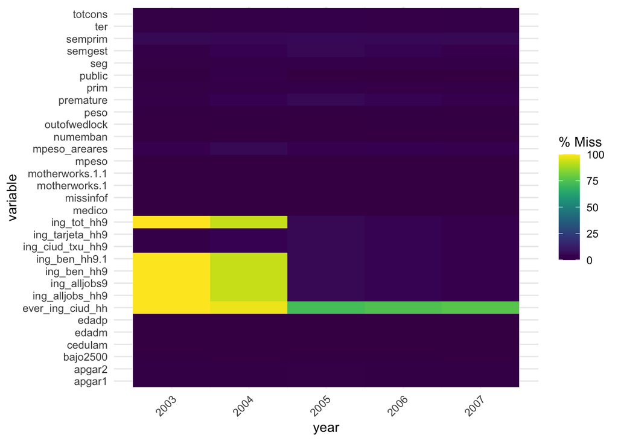

```r
gg_miss_fct(df_subset,year)
```

### 4.3.8. See the pattern of the missing values.

1. Missing observations per variable

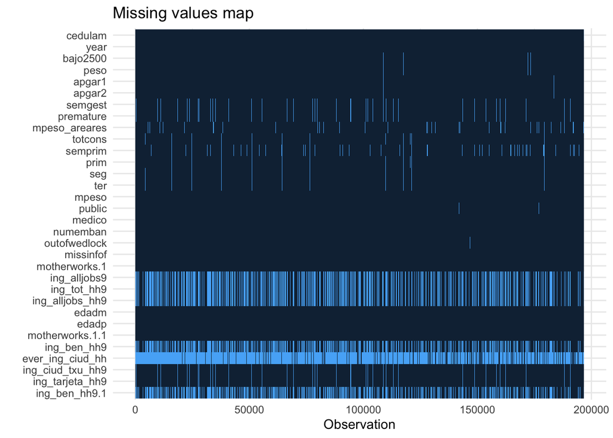

```r
df_subset %>%
  missing_plot()
```

### 4.3.9. Solutions if missing values is at random

IMPORTANT: ALWAYS REPORT HOW YOU HANDLE MISSING VALUES.

1. Do not consider missing values in the estimation

```r
    mean(df_subset$mpeso_areares)
```

```
## [1] NA
```

```
Nop! we did not mean that.  We cannot just ignore missing values in R as you need to specify this.

We meant eliminating missing values.  The problem is that we might end up with a very small sample.
```

```r
  mean(df_subset$mpeso_areares,na.rm=T)
```

```
## [1] 3198.199
```

Not equivalent to dropping missing values. As you can see in the next point, we obtain a different mean when we drop values. Why?

2. Listwise deletion (Drop missing values, and keep only completed cases): this is only valid when data is missing completely at random (MCAR). MCAR means that the probability of missingness is independent of the variable of interest and the rest of observed variables. MCAR causes large standard errors but not bias. If missingnes is not at random, then deletion introduces biases as the data is not longer representative of the population (if the original sample was a representative sample of the population of interest).

```r
# Use tidyverse package to drop missing values
df_subset_nona_tv<-df_subset %>% drop_na()

# Alternative way of dropping missing values
  df_subset_nona<-na.omit(df_subset)
```

```r
  mean(df_subset_nona$mpeso_areares)
```

```
## [1] 3192.892
```

```r
  mean(df_subset_nona_tv$mpeso_areares)
```

```
## [1] 3192.892
```

3. Impute missing values: valid if data is missing at random (MAR) since the probability of missigness depends on the other observed variable.

Impute with the mean of the variable

```r
  imputed <- df_subset %>%
  mutate(mpeso_areares = replace_na(mpeso_areares, mean(mpeso_areares, na.rm = T)))

  head(imputed$mpeso_areares)
```

```
## [1] 3148.675 3198.199 3135.173 3148.675 3145.420 3198.199
```

Note: there different types of imputation methods: multivariate, regression based, etc. We only see one due to scope of course.

## 4.4 Look for outliers

Detection of outliers: use graphical analysis, or use other diagnostics (out of the scope of the course)

Reasons of outliers:

- Errors: human, measurement, data processing, sampling. In this situation one can throw away the value.
- Extreme value or novelty: legitimate outlier, do not it throw away!!!

### 4.4.1 Graphical analysis

#### 1. Unidimensional analysis:

```
See if the variable birthweight has outliers using descriptive statistics, plotting the empirical distribution, a boxplot.
```

```r
# Quantiles, maximum, minimum
summary(df_subset$peso)
```

```
##    Min. 1st Qu.  Median    Mean 3rd Qu.    Max.    NA's
##     500    2920    3250    3218    3565    8000     533
```

```r
quantile(df_subset_nona$peso, c(.25, .5, .75, .95))
```

```
##  25%  50%  75%  95%
## 2900 3220 3540 4025
```

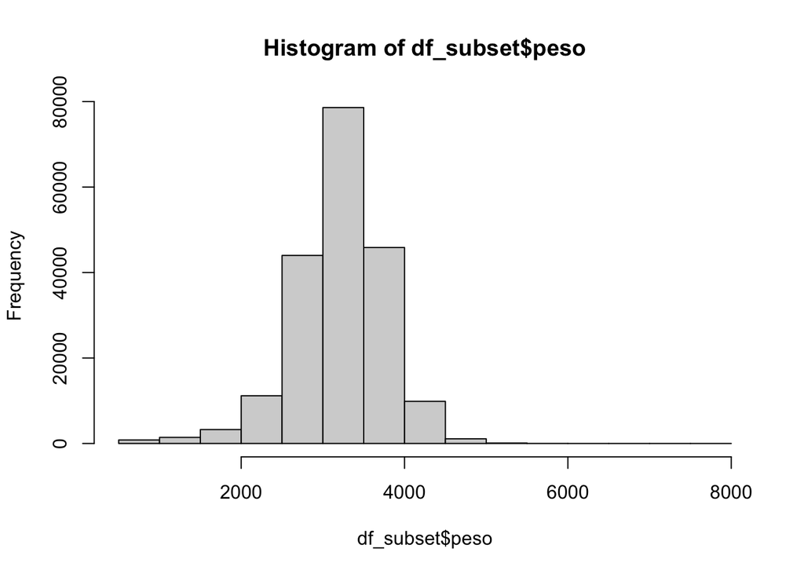

```r
# Histogram
hist(df_subset$peso)
```

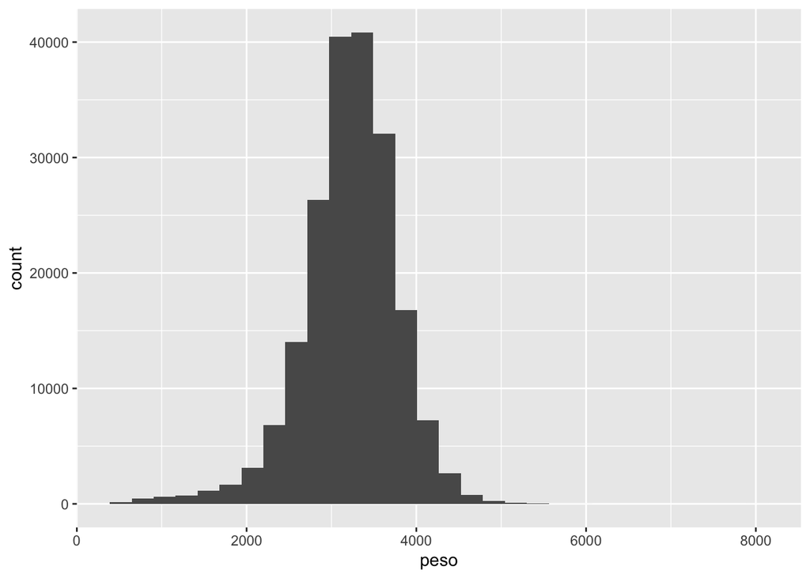

```r
# Histogram using ggplot2 library
ggplot(df_subset, aes(x=peso)) + geom_histogram()
```

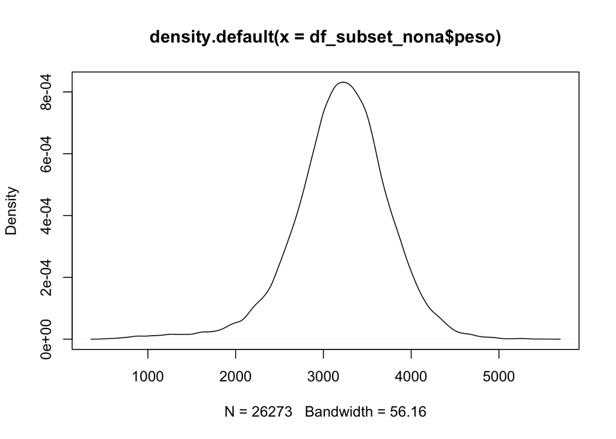

```r
# Density
d<-density(df_subset_nona$peso)
plot(d)
```

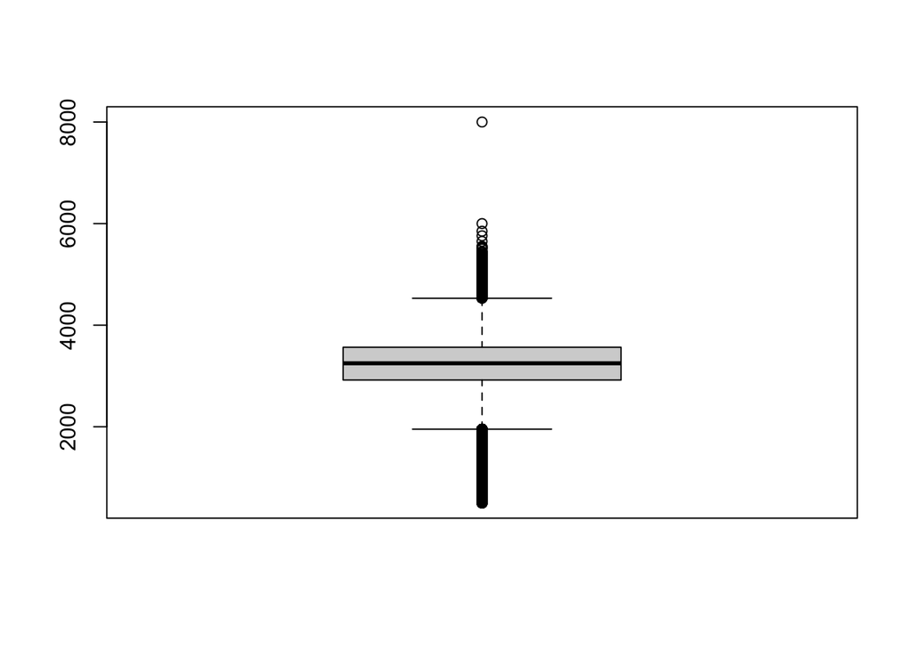

```r
# Simplest way of graphing a boxplot
boxplot(df_subset$peso)
```

We observe an outlier, a newborn with weight 8kg! It is very likely that this value is an error. We can use a bivariate analysis to gather more evidence on the reason of the outlier.

#### 2. Bivariate analysis:

```
We can see if the variable birthweight has outliers in terms of the variability of the gestational term. If we find that the 8kg newborn was born with a gestational term of 26 weeks, then it is evidence that it is a mistake and that the value is not credible.
```

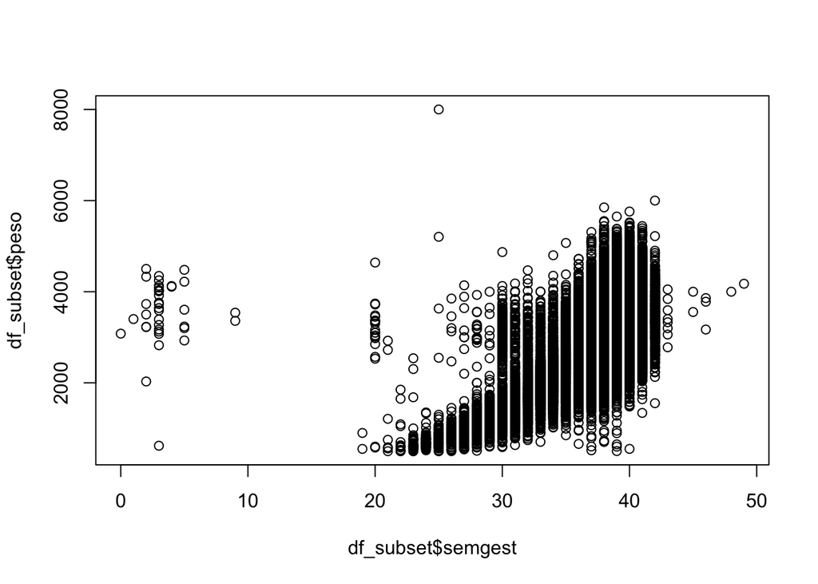

```r
# Simplest way of graphing a boxplot
plot(df_subset$semgest,df_subset$peso)
```

```r
# Using ggplot2 library
```

[output not shown]

There are other methods to identify outliers but it is more advanced and out os the scope of this course.

#### 3. Solutions for legitimate outliers

1. Robust estimation (out of the scope of the course)
2. Using other weights (out of the scope of the course)

# Step 5. Exploratory Analysis

## 5.1 Summary statistics

```r
summary(df_subset)
```

```
##     cedulam            year         bajo2500           peso
##  Min.   :    10   Min.   :2003   Min.   :0.0000   Min.   : 500
##  1st Qu.:161370   1st Qu.:2004   1st Qu.:0.0000   1st Qu.:2920
##  Median :288806   Median :2005   Median :0.0000   Median :3250
##  Mean   :287283   Mean   :2005   Mean   :0.0814   Mean   :3218
##  3rd Qu.:400938   3rd Qu.:2006   3rd Qu.:0.0000   3rd Qu.:3565
##  Max.   :757784   Max.   :2007   Max.   :1.0000   Max.   :8000
##  NA's   :1                       NA's   :533      NA's   :533
##      apgar1           apgar2          semgest        premature
##  Min.   : 0.000   Min.   : 0.000   Min.   : 0.00   Min.   :0.000
##  1st Qu.: 8.000   1st Qu.: 9.000   1st Qu.:38.00   1st Qu.:0.000
##  Median : 9.000   Median :10.000   Median :39.00   Median :0.000
##  Mean   : 8.499   Mean   : 9.622   Mean   :38.57   Mean   :0.088
##  3rd Qu.: 9.000   3rd Qu.:10.000   3rd Qu.:40.00   3rd Qu.:0.000
##  Max.   :10.000   Max.   :10.000   Max.   :49.00   Max.   :1.000
##  NA's   :1482     NA's   :1486     NA's   :7334    NA's   :7334
##  mpeso_areares     totcons          semprim           prim
##  Min.   :2931   Min.   : 0.000   Min.   : 0.40   Min.   : 0.0000
##  1st Qu.:3166   1st Qu.: 6.000   1st Qu.: 9.00   1st Qu.: 0.0000
##  Median :3194   Median : 9.000   Median :13.00   Median : 0.0000
##  Mean   :3198   Mean   : 8.103   Mean   :14.47   Mean   : 0.5944
##  3rd Qu.:3218   3rd Qu.:10.000   3rd Qu.:18.00   3rd Qu.: 1.0000
##  Max.   :3609   Max.   :30.000   Max.   :42.00   Max.   :17.0000
##  NA's   :8123   NA's   :2801     NA's   :10606   NA's   :2731
##       seg              ter            mpeso          public
##  Min.   : 0.000   Min.   : 0.00   Min.   :1995   Min.   :0.0000
##  1st Qu.: 1.000   1st Qu.: 4.00   1st Qu.:3164   1st Qu.:0.0000
##  Median : 2.000   Median : 5.00   Median :3216   Median :0.0000
##  Mean   : 2.139   Mean   : 5.37   Mean   :3199   Mean   :0.4228
##  3rd Qu.: 3.000   3rd Qu.: 7.00   3rd Qu.:3254   3rd Qu.:1.0000
##  Max.   :19.000   Max.   :20.00   Max.   :3735   Max.   :1.0000
##  NA's   :2749     NA's   :2759    NA's   :48     NA's   :786
##      medico          numemban      outofwedlock     missinfof
##  Min.   :0.0000   Min.   : 0.00   Min.   :0.000   Min.   :0.0000
##  1st Qu.:0.0000   1st Qu.: 0.00   1st Qu.:0.000   1st Qu.:0.0000
##  Median :1.0000   Median : 1.00   Median :1.000   Median :0.0000
##  Mean   :0.6708   Mean   : 1.39   Mean   :0.619   Mean   :0.4041
##  3rd Qu.:1.0000   3rd Qu.: 2.00   3rd Qu.:1.000   3rd Qu.:1.0000
##  Max.   :1.0000   Max.   :40.00   Max.   :1.000   Max.   :1.0000
##                                   NA's   :414
```

[output cut: 9 more lines]

```
##  Min.   :   3   Min.   :   0   Min.   :0.0000   Min.   : 0.00
##  1st Qu.:  21   1st Qu.:  30   1st Qu.:0.0000   1st Qu.: 0.00
##  Median :  27   Median :  40   Median :0.0000   Median : 0.00
##  Mean   : 162   Mean   :4237   Mean   :0.3563   Mean   : 0.22
##  3rd Qu.:  32   3rd Qu.:9999   3rd Qu.:1.0000   3rd Qu.: 0.00
##  Max.   :9999   Max.   :9999   Max.   :1.0000   Max.   :16.83
##                                                 NA's   :83722
##  ever_ing_ciud_hh ing_ciud_txu_hh9 ing_tarjeta_hh9 ing_ben_hh9.1
##  Min.   :0.00     Min.   :0.000    Min.   :0.000   Min.   : 0.00
##  1st Qu.:0.00     1st Qu.:0.000    1st Qu.:0.000   1st Qu.: 0.00
##  Median :1.36     Median :0.000    Median :0.000   Median : 0.00
##  Mean   :0.93     Mean   :0.061    Mean   :0.014   Mean   : 0.22
##  3rd Qu.:1.36     3rd Qu.:0.000    3rd Qu.:0.000   3rd Qu.: 0.00
##  Max.   :1.37     Max.   :2.254    Max.   :1.227   Max.   :16.83
##  NA's   :166795   NA's   :7334     NA's   :7334    NA's   :83722
```

## 5.1 Summary statistics by group

```r
df_subset_nona %>%
  group_by(motherworks.1) %>%
  summarize(mean = mean(peso),
            std = sd(peso))
```

```
## # A tibble: 2 × 3
##   motherworks.1  mean   std
##           <int> <dbl> <dbl>
## 1             0 3193.  545.
## 2             1 3241.  548.
```

# Step 6. Modelling

## 6.1 Linear regression

```r
linear_model<-lm(df_subset$peso~df_subset$semgest+df_subset$motherworks.1+df_subset$motherworks.1*df_subset$semgest)
summary(linear_model)
```

```
##
## Call:
## lm(formula = df_subset$peso ~ df_subset$semgest + df_subset$motherworks.1 +
##     df_subset$motherworks.1 * df_subset$semgest)
##
## Residuals:
##     Min      1Q  Median      3Q     Max
## -2940.9  -283.9   -17.1   266.2  7395.1
##
## Coefficients:
##                                             Estimate Std. Error  t value
## (Intercept)                               -3228.4024    24.2349 -133.213
## df_subset$semgest                           166.6382     0.6277  265.478
## df_subset$motherworks.1                      59.0229    41.4494    1.424
## df_subset$semgest:df_subset$motherworks.1    -0.1321     1.0728   -0.123
##                                           Pr(>|t|)
## (Intercept)                                 <2e-16 ***
## df_subset$semgest                           <2e-16 ***
## df_subset$motherworks.1                      0.154
## df_subset$semgest:df_subset$motherworks.1    0.902
## ---
## Signif. codes:  0 '***' 0.001 '**' 0.01 '*' 0.05 '.' 0.1 ' ' 1
##
## Residual standard error: 441.9 on 189015 degrees of freedom
##   (7685 observations deleted due to missingness)
## Multiple R-squared:  0.3635, Adjusted R-squared:  0.3635
## F-statistic: 3.598e+04 on 3 and 189015 DF,  p-value: < 2.2e-16
```

## 6.2 Polynomial regression

```r
quadratic_model<-lm(df_subset_nona$peso~poly(df_subset_nona$semgest,2)*df_subset_nona$motherworks.1)
summary(quadratic_model)
```

```
##
## Call:
## lm(formula = df_subset_nona$peso ~ poly(df_subset_nona$semgest,
##     2) * df_subset_nona$motherworks.1)
##
## Residuals:
##     Min      1Q  Median      3Q     Max
## -2417.2  -285.6   -15.1   270.3  3854.3
##
## Coefficients:
##                                                                 Estimate
## (Intercept)                                                     3193.936
## poly(df_subset_nona$semgest, 2)1                               52228.450
## poly(df_subset_nona$semgest, 2)2                                6137.758
## df_subset_nona$motherworks.1                                      41.695
## poly(df_subset_nona$semgest, 2)1:df_subset_nona$motherworks.1   3857.614
## poly(df_subset_nona$semgest, 2)2:df_subset_nona$motherworks.1 -11448.275
##                                                               Std. Error
## (Intercept)                                                        2.903
## poly(df_subset_nona$semgest, 2)1                                 468.616
## poly(df_subset_nona$semgest, 2)2                                 450.082
## df_subset_nona$motherworks.1                                       7.871
## poly(df_subset_nona$semgest, 2)1:df_subset_nona$motherworks.1   1345.509
## poly(df_subset_nona$semgest, 2)2:df_subset_nona$motherworks.1   1978.097
##                                                                t value Pr(>|t|)
## (Intercept)                                                   1100.039  < 2e-16
## poly(df_subset_nona$semgest, 2)1                               111.453  < 2e-16
## poly(df_subset_nona$semgest, 2)2                                13.637  < 2e-16
## df_subset_nona$motherworks.1                                     5.297 1.19e-07
## poly(df_subset_nona$semgest, 2)1:df_subset_nona$motherworks.1    2.867  0.00415
## poly(df_subset_nona$semgest, 2)2:df_subset_nona$motherworks.1   -5.788 7.22e-09
##
## (Intercept)                                                   ***
## poly(df_subset_nona$semgest, 2)1                              ***
## poly(df_subset_nona$semgest, 2)2                              ***
## df_subset_nona$motherworks.1                                  ***
## poly(df_subset_nona$semgest, 2)1:df_subset_nona$motherworks.1 **
## poly(df_subset_nona$semgest, 2)2:df_subset_nona$motherworks.1 ***
## ---
## Signif. codes:  0 '***' 0.001 '**' 0.01 '*' 0.05 '.' 0.1 ' ' 1
##
## Residual standard error: 437.4 on 26267 degrees of freedom
## Multiple R-squared:  0.3578, Adjusted R-squared:  0.3576
## F-statistic:  2926 on 5 and 26267 DF,  p-value: < 2.2e-16
```

CAUTION: we are not estimating causal relationships, only correlations.

# Step 7. Model evaluation

## 7.1 Plot residuals

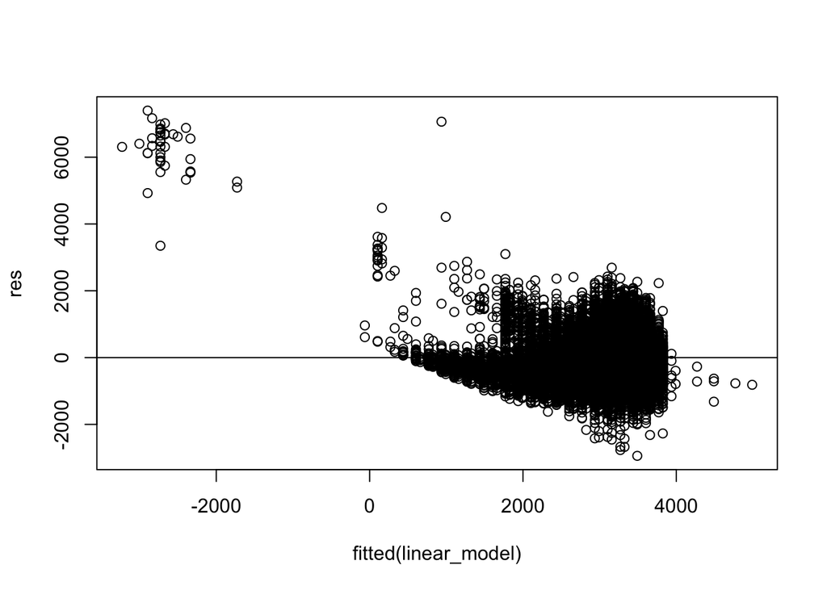

```r
#get list of residuals
res <- resid(linear_model)
plot(fitted(linear_model), res)
abline(0,0)
```

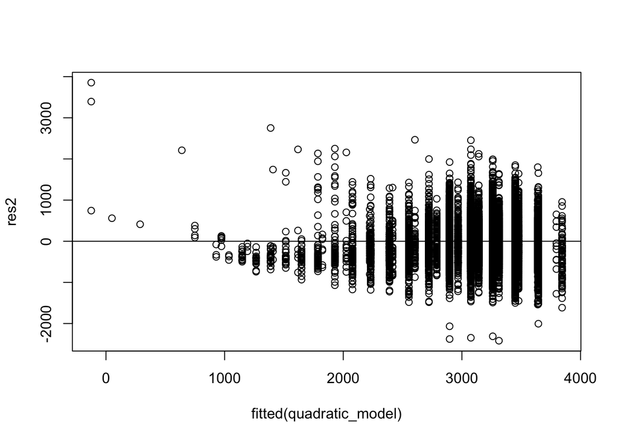

```r
#get list of residuals
res2 <- resid(quadratic_model)
plot(fitted(quadratic_model), res2)
abline(0,0)
```

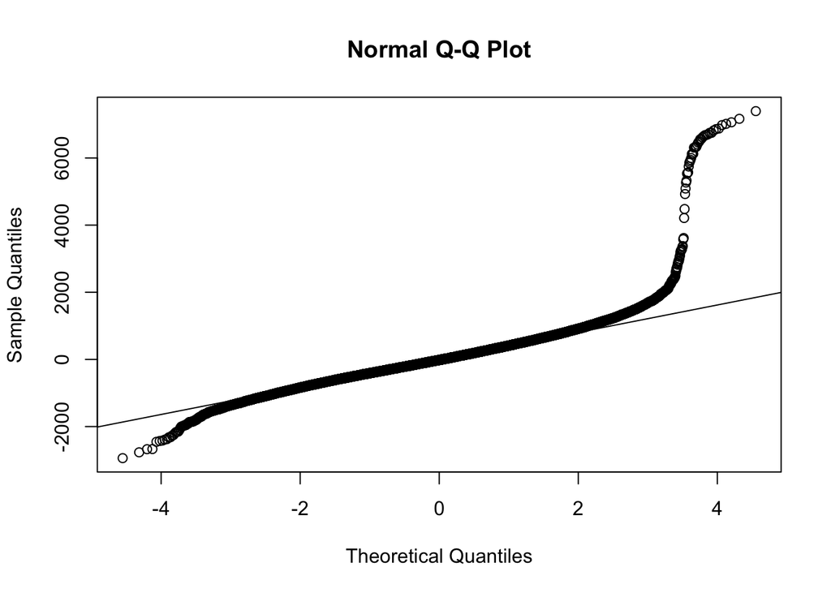

```r
#create Q-Q plot for residuals
qqnorm(res)

#add a straight diagonal line to the plot
qqline(res)
```

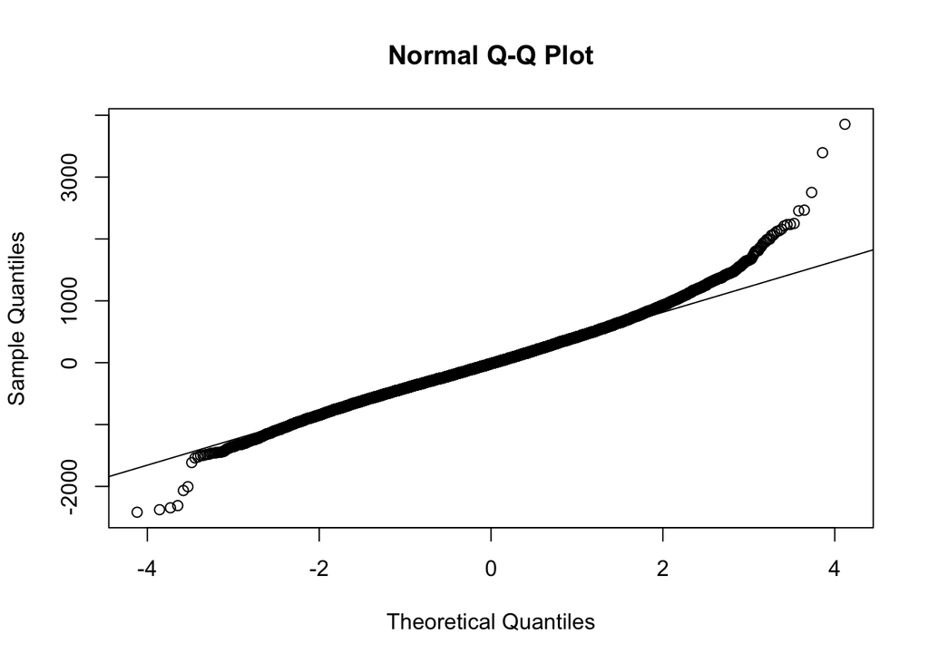

```r
#create Q-Q plot for residuals
qqnorm(res2)

#add a straight diagonal line to the plot
qqline(res2)
```

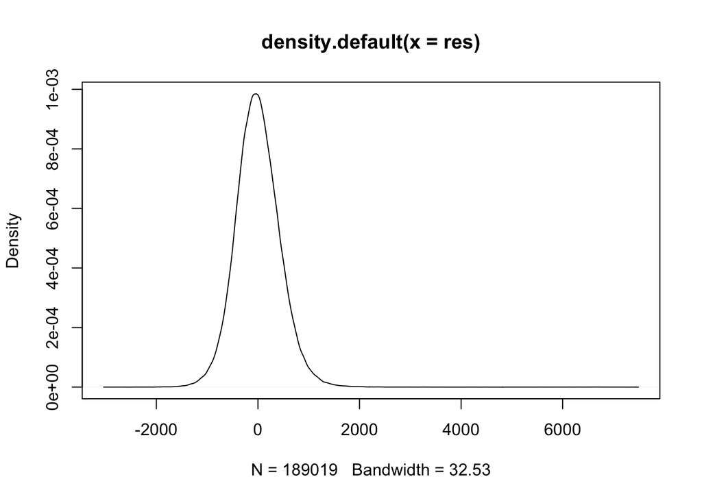

```r
#Create density plot of residuals
plot(density(res))
```

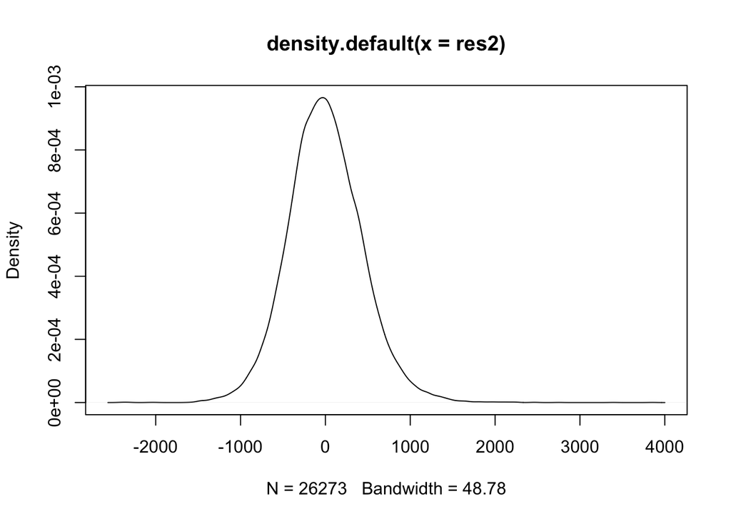

```r
#Create density plot of residuals
plot(density(res2))
```

# REFERENCES

1. Amarante, V., Manacorda, M., Miguel, E., & Vigorito, A. (2016). Do cash transfers improve birth outcomes? Evidence from matched vital statistics, and program and social security data. American Economic Journal: Economic Policy, 8(2), 1-43.
2. More information on manipulating variables with tidyverse: https://tavareshugo.github.io/r-intro-tidyverse-gapminder/04-manipulate_variables_dplyr/index.html
3. https://epirhandbook.com/en/missing-data.html
4. https://cran.r-project.org/web/packages/naniar/vignettes/naniar-visualisation.html
5. https://thedocs.worldbank.org/en/doc/20f02031de132cc3d76b91b5ed8737d0-0050012017/related/lecture-12-1.pdf